# Мобильная игра "Mines & Moles"

**Факторный анализ причин падения выручки: от расчёта продуктовых метрик до визуализации и интерпретации результатов**

## Описание задачи

Mines & Moles - однопользовательская мобильная игра в жанре rogue-like. Цель игры — прохождение уровней, каждый из которых представляет собой сложную систему подземных шахт.  
Алгоритм игры генерирует наполнение уровней случайным образом. Задача игрока — избежать опасностей (ловушек и монстров) и собрать ценные предметы, например оружие и золото. Все уровни проходятся линейно — игрок не может перейти на следующий уровень, не завершив текущий. Создатели игры заинтересованы в том, чтобы пользователи не застревали на уровнях и не начинали их заново по многу раз. Это вызывает у игроков раздражение и приводит к оттоку аудитории. Маркетинговые исследования показали, что большинство пользователей начинают «залипать» в игру и делать покупки в магазине после прохождения 10 уровней.

**Торговля в игре**

Источник монетизации — покупки пользователей во внутриигровом магазине. Игроки могут покупать:

- Наборы с монетами, которые в дальнейшем можно обменивать на полезные для прохождения уровней предметы.
- Наборы скинов для персонажа.
- Монстров, уровни, предметы.
- Сундуки со случайно генерируемыми усилениями. К ним относятся, например, дополнительные жизни и способность проходить сквозь стены. Усиления помогают пройти особо сложные уровни.

Для игры и покупок в магазине регистрироваться в игре необязательно. Оплачивать покупки можно банковской картой, PayPal или внутриигровой валютой.

**Технические особенности и доступ**

Игра доступна для операционных систем Android и iOS в магазинах приложений России, Казахстана, Беларуси, Узбекистана, Армении, Киргизии, Азербайджана и Грузии.

Пользователи приходят в продукт тремя способами:

- прямое скачивание (органические пользователи);
- реклама в Google, Yandex, VK и партнёрских сетях;
- реферальные программы.

### Кейс

В начале 2024 года продукт достаточно активно рос: увеличивалась активная аудитория и выручка внутриигрового магазина. Но с июля 2024 года менеджеры начали фиксировать сначала стагнацию, а затем и снижение выручки от месяца к месяцу.

Никаких технических проблем не фиксировалось, но летом произошли изменения в пользовательском опыте: редизайн внутриигрового магазина и корректировка алгоритма, который генерирует уровни.

### Цели и задачи проекта

Найти причину проблемы: определить, в какой части продукта произошла поломка. Сформулировать выводы и презентовать их команде продукта.

### Описание данных

**Подготовленный датасет - dataset** - для расчета метрик MAU и Retention Rate по месяцам

- device_id — идентификатор устройства пользователя, на которое установлена игра,
- first_activity_month - месяц первой активности пользователя в игре
- all_activity_month - месяц активности пользователя в игре
- platform операционная система устройства, на которое установлена игра (iOS или Android)
- country_code - код страны пользователя (определяется по магазину приложений, в котором была скачана игра)
- traffic_type - тип источника привлечения пользователя (органический, платный, реферальный)

**Данные пользователей - users**

- device_id — идентификатор устройства пользователя, на которое установлена игра
- user_id — идентификатор зарегистрированного в игре пользователя, NULL — если пользователь не зарегистрирован
- install_time — дата и время установки приложения
- country_code — код страны пользователя (определяется по магазину приложений, в котором была скачана игра)
- platform — операционная система устройства, на которое установлена игра (iOS или Android)
- traffic_type — тип источника привлечения пользователя (органический, платный, реферальный)
- source — конкретный источник привлечения пользователя
- campaign — идентификатор рекламной кампании (только для платного трафика, для остальных — NULL)

**Данные о событиях - таблица events**

- device_id — уникальный идентификатор устройства пользователя
- session_id — идентификатор сессии пользователя
- time — дата и время события
- event_name — название события

**Данные о прохождении уровней - таблица game_sessions**

- device_id — уникальный идентификатор устройства пользователя
- session_id — идентификатор сессии пользователя
- level_id — идентификатор уровня
- time_start — дата и время начала прохождения уровня
- time_end — дата и время окончания прохождения уровня
- success_fact — завершение уровня пользователем: 1 — завершён, 0 — не завершён
- duration_sec — длительность прохождения уровня в секундах (type: Int).

**Данные о транзакциях в игровом магазине - таблица transactions**

- device_id — уникальный идентификатор устройства пользователя (
- session_id — идентификатор сессии пользователя
- transaction_id — идентификатор транзакции
- time — дата и время транзакции
- payment_type — способ оплаты (банковская карта, PayPal, внутриигровой кошелёк)
- item_name — название товара в магазине
- price — цена товара в долларах
- status — результат транзакции (success — оплата прошла успешно, failed — оплата не прошла)

## Анализ дерева метрик

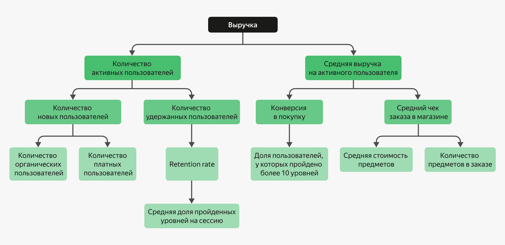

На основе дерева метрик продукта выбираем наиболее подходящие **гипотезы** о причинах снижения выручки.

**1. Выручка упала из-за снижения активной аудитории продукта.**

**1 гипотеза:** ухудшилась стратегия привлечения новых пользователей: если продукт недостаточно хорошо привлекает новых пользователей и их приток снизился, это приведёт к уменьшению активной аудитории.

**Проверяемые метрики:**

- Количество новых пользователей, которые пришли из органического канала,
- Количество новых пользователей, которые пришли из платного или реферального канала.

**2 гипотеза:** опыт текущих пользователей в игре ухудшается, что приводит к увеличению оттока. Это плохо сказывается на размере активной аудитории.

**Проверяемые метрики:**

- Retention Rate по когортам пользователей,
- Средняя доля пройденных уровней на сессию.

**2. Выручка упала из-за снижения среднего дохода на активного пользователя.**

**1 гипотеза:** Пользователи стали покупать меньше товаров - уменьшение количества предметов в заказах ведет к снижению среднего дохода на активного пользователя.

**Проверяемые метрики:**

- Среднее количество предметов в заказе.

**2 гипотеза:** Пользователи стали покупать более дешёвые предметы - это снижает средний доход на активного пользователя.

**Проверяемые метрики:**

- Средняя цена предметов в заказе.

**3 гипотеза:** Пользователи стали менее активно совершать покупки - это ведёт к падению конверсии в покупку и к снижению среднего дохода на активного пользователя.

**Проверяемые метрики:**

- Воронка конверсии от запуска приложения до покупки предметов во внутриигровом магазине,
- Доля пользователей, у которых пройдено более 10 уровней

## Загрузка библиотек

```python
# Загружаем библиотеку Pandas
import pandas as pd
```

```python
# Загружаем библиотеки для визуализации данных
import matplotlib.pyplot as plt
import matplotlib.colors as mcolors
import seaborn as sns
```

```python
# Уменьшение разрешения DPI для графиков
plt.rcParams['figure.dpi'] = 72
```

## Загрузка данных

```python
# Выгружаем данные из файла `.csv` в датафрейм
try:
    #пробуем загрузить
    df = pd.read_csv('datasets/PA_2_7_1_dataset.csv')
    display('Данные успешно загружены')
except:
    # если не получилось
    display('Ошибка при загрузке файла')
```

```
'Данные успешно загружены'
```

```python
df.head()
```

|  | device_id | first_activity_month | all_activity_month | platform | country_code | traffic_type |
| --- | --- | --- | --- | --- | --- | --- |
| 0 | 000241fd-d220-413e-aeef-36c7bc9a4b22 | 2024-09-01 | 2024-09-01 | ios | RU | organic |
| 1 | 000241fd-d220-413e-aeef-36c7bc9a4b22 | 2024-09-01 | 2024-12-01 | ios | RU | organic |
| 2 | 000d2a74-9158-4ae4-8c3c-5d6afe4efee0 | 2024-10-01 | 2024-10-01 | android | AM | referral |
| 3 | 000d2a74-9158-4ae4-8c3c-5d6afe4efee0 | 2024-10-01 | 2024-12-01 | android | AM | referral |
| 4 | 000e5525-a8e9-40ee-95a5-ecb115e75f52 | 2024-04-01 | 2024-04-01 | ios | KZ | organic |

```python
try:
    df_sessions = pd.read_csv('datasets/PA_2_7_1_game_sessions.csv')
    display('Данные успешно загружены')
except:
    display('Ошибка при загрузке файла')
```

```
'Данные успешно загружены'
```

```python
df_sessions.head()
```

|  | device_id | session_id | level_id | time_start | time_end | success_fact | duration_sec |
| --- | --- | --- | --- | --- | --- | --- | --- |
| 0 | 1a239539-b83c-452c-a3a6-b6f1554aa8e0 | 1 | 1 | 2024-01-03 13:55:08 | 2024-01-03 13:56:18 | 0 | 70 |
| 1 | 1a239539-b83c-452c-a3a6-b6f1554aa8e0 | 1 | 1 | 2024-01-03 13:56:19 | 2024-01-03 14:01:18 | 0 | 299 |
| 2 | 1a239539-b83c-452c-a3a6-b6f1554aa8e0 | 1 | 1 | 2024-01-03 14:01:19 | 2024-01-03 14:02:16 | 0 | 57 |
| 3 | 1a239539-b83c-452c-a3a6-b6f1554aa8e0 | 1 | 1 | 2024-01-03 14:02:17 | 2024-01-03 14:04:37 | 1 | 140 |
| 4 | 1a239539-b83c-452c-a3a6-b6f1554aa8e0 | 2 | 2 | 2024-01-06 16:38:12 | 2024-01-06 16:42:18 | 1 | 246 |

```python
try:
    df_transactions = pd.read_csv('datasets/PA_2_7_1_transactions.csv')
    display('Данные успешно загружены')
except:
    display('Ошибка при загрузке файла')
```

```
'Данные успешно загружены'
```

```python
df_transactions.head()
```

|  | device_id | session_id | transaction_id | time | payment_type | item_name | price | status |
| --- | --- | --- | --- | --- | --- | --- | --- | --- |
| 0 | 000e5525-a8e9-40ee-95a5-ecb115e75f52 | 16 | 655147 | 2024-04-20 02:16:42 | bank_card | chest_2 | 26 | success |
| 1 | 000e5525-a8e9-40ee-95a5-ecb115e75f52 | 22 | 623531 | 2024-04-23 02:09:59 | bank_card | chest_3 | 33 | success |
| 2 | 000e5525-a8e9-40ee-95a5-ecb115e75f52 | 23 | 561298 | 2024-04-23 16:08:54 | bank_card | skin_bundle_2 | 25 | success |
| 3 | 000e5525-a8e9-40ee-95a5-ecb115e75f52 | 28 | 208171 | 2024-04-25 20:52:12 | bank_card | chest_1 | 22 | success |
| 4 | 000e5525-a8e9-40ee-95a5-ecb115e75f52 | 29 | 246478 | 2024-04-26 21:42:50 | bank_card | coin_pack_3 | 40 | success |

```python
try:
    df_events = pd.read_csv('datasets/PA_2_7_1_events.csv')
    display('Данные успешно загружены')
except:
    display('Ошибка при загрузке файла')
```

```
'Данные успешно загружены'
```

```python
 df_events.head()
```

|  | device_id | session_id | time | event_name |
| --- | --- | --- | --- | --- |
| 0 | 1a239539-b83c-452c-a3a6-b6f1554aa8e0 | 1 | 2024-01-03 13:55:03 | app_start |
| 1 | 1a239539-b83c-452c-a3a6-b6f1554aa8e0 | 1 | 2024-01-03 13:55:08 | game_launched |
| 2 | 1a239539-b83c-452c-a3a6-b6f1554aa8e0 | 2 | 2024-01-06 16:38:05 | app_start |
| 3 | 1a239539-b83c-452c-a3a6-b6f1554aa8e0 | 2 | 2024-01-06 16:38:12 | game_launched |
| 4 | 1a239539-b83c-452c-a3a6-b6f1554aa8e0 | 3 | 2024-01-08 01:51:26 | app_start |

```python
try:
    df_users = pd.read_csv('datasets/PA_2_7_1_users.csv')
    display('Данные успешно загружены')
except:
    display('Ошибка при загрузке файла')
```

```
'Данные успешно загружены'
```

```python
df_users.head()
```

|  | device_id | install_time | country_code | traffic_type | platform | source | campaign | user_id |
| --- | --- | --- | --- | --- | --- | --- | --- | --- |
| 0 | 936e9358-48eb-4b9f-936e-d8ab0dabb3d6 | 2024-01-02 08:50:22 | BY | organic | ios | direct_app_download | NaN | 1.0 |
| 1 | 4e12bd6f-165e-460a-8de2-b8b29391a23a | 2024-01-21 22:58:48 | RU | organic | android | direct_app_download | NaN | 3.0 |
| 2 | 0a7285ff-90b5-4809-a8cd-f60c09b97aca | 2024-01-21 08:59:45 | RU | paid | ios | youtube | yt1 | 4.0 |
| 3 | 86426e8e-f66b-4508-b69e-38967707dbe3 | 2024-01-28 16:24:02 | KZ | paid | ios | instagram | ig1 | 5.0 |
| 4 | 328dc9d1-0366-459a-b603-882710ab5031 | 2024-01-19 18:45:09 | RU | organic | ios | direct_app_download | NaN | NaN |

## Расчет метрик

### MAU по всем пользователям

MAU - Количество уникальных пользователей приложения за месяц

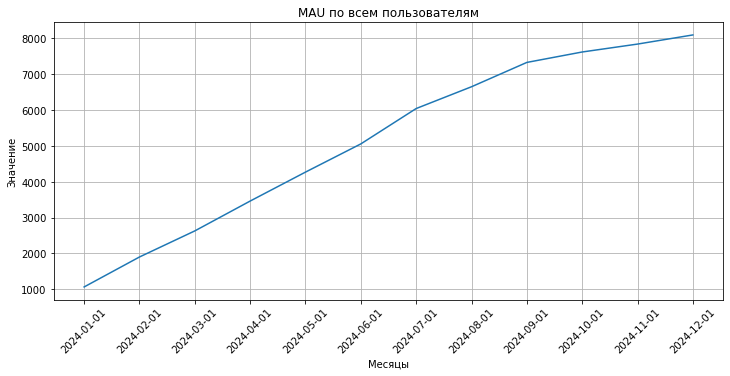

```python
mau_all = df.groupby('all_activity_month')['device_id'].nunique().reset_index()

plt.subplots(figsize=(12,5))
plt.plot(
    mau_all['all_activity_month'],
    mau_all['device_id'])

plt.title('MAU по всем пользователям')
plt.xlabel('Месяцы')
plt.ylabel('Значение')
plt.xticks(rotation=45)
plt.grid()
plt.show()
```

**Вывод:** Показатель MAU демонстрирует стабильный рост, хотя с сентября темпы роста немного снизились.

### MAU в разрезе платформ пользователей

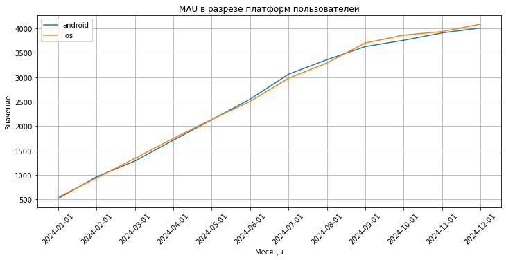

```python
mau_platforms = df.groupby(['all_activity_month','platform'])['device_id'].nunique().reset_index()

platform_list = mau_platforms['platform'].unique()
plt.subplots(figsize=(12,5))

for platform_ in platform_list:
    plt.plot(
        mau_platforms.loc[mau_platforms['platform'] == platform_]['all_activity_month'],
        mau_platforms.loc[mau_platforms['platform'] == platform_]['device_id'])

plt.title('MAU в разрезе платформ пользователей')
plt.legend(platform_list)
plt.xlabel('Месяцы')
plt.ylabel('Значение')
plt.xticks(rotation=45)
plt.grid()
plt.show()
```

**Вывод:** Показатель MAU (Количество уникальных пользователей приложения за месяц) в разрезе платформ практически одинаков по обеим платформам. Проседаний нет ни по одной платформе.

### Количество новых пользователей по источникам привлечения в динамике по месяцам

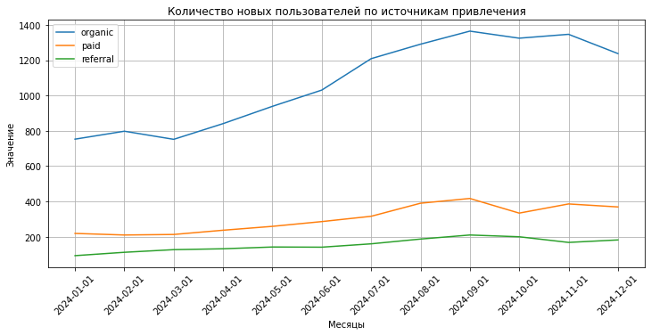

```python
new_users = df.groupby(['first_activity_month','traffic_type'])['device_id'].nunique().reset_index()

traffic_list = new_users['traffic_type'].unique()
plt.subplots(figsize=(12,5)) # параметры размера графика

for traffic in traffic_list:
    plt.plot(
        new_users.loc[new_users['traffic_type'] == traffic]['first_activity_month'],
        new_users.loc[new_users['traffic_type'] == traffic]['device_id'])

plt.title('Количество новых пользователей по источникам привлечения')
plt.legend(traffic_list)
plt.xlabel('Месяцы')
plt.ylabel('Значение')
plt.xticks(rotation=45)
plt.grid()
plt.show()
```

### Retention Rate по когортам

Retention Rate (коэффициент удержания клиентов) — это метрика, показывающая процент пользователей, которые возвращаются в приложение в течение определенного времени. Визуализируем RR в динамике по месяцам по когортам.

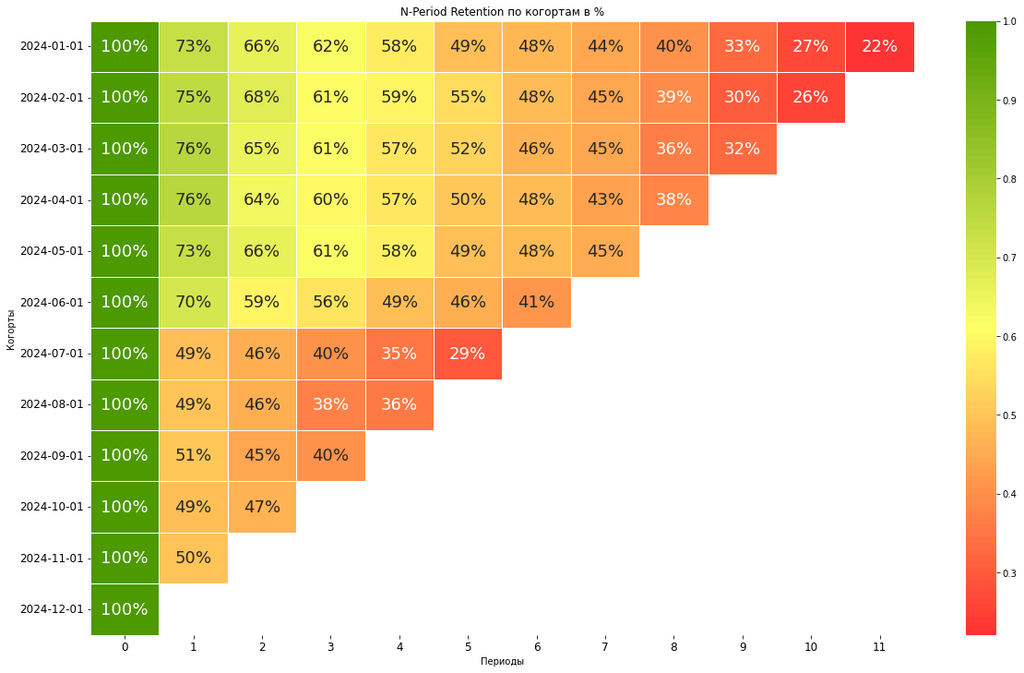

```python
cmap = mcolors.LinearSegmentedColormap.from_list('green_red', ['#FF3333', '#FFFF66', '#4C9900'], N=100)

df['first_activity_month'] = pd.to_datetime(df['first_activity_month']).dt.date
df['all_activity_month'] = pd.to_datetime(df['all_activity_month'])


df['n_period'] = (
    df['all_activity_month'].dt.to_period('M').astype('int64')
    - pd.to_datetime(df['first_activity_month']).dt.to_period('M').astype('int64')
)
data_pivot = pd.pivot_table(df,
                            values='device_id',
                            index='first_activity_month',
                            columns='n_period',
                            aggfunc=pd.Series.nunique).fillna(0).astype(int)

data_pivot = data_pivot.div(data_pivot[0], axis=0)

# Заменяем нули на пустые значения NaN. Это необходимо для корректной отрисовки визуализации в дальнейшем.
# Чтобы нули не были видны на графиках, заменим их на NaN.
data_pivot[data_pivot == 0] = float('nan')

plt.subplots(figsize=(20,12))
sns.heatmap(data_pivot,
           cmap=cmap,
           annot=True,
           fmt='.0%',
           linewidth=0.5,
           annot_kws={"size": 18})

plt.title('N-Period Retention по когортам в %')
plt.xlabel('Периоды')
plt.ylabel('Когорты')
plt.yticks(rotation=0)
plt.tick_params(labelsize=12) # делаем подписи данных на оси Y (когорты пользователей) немного крупнее
plt.show()
```

**Вывод:** RR по когортам демонстрирует проблемы, начиная с июля-августа: пользователи, зарегистрировавшиеся в приложении в июле, имеют уже в следующем месяце (август) показатель RR ниже на 20-25% ниже, чем у пользователей, зарегистрированных до этого.

### Доля пройденных уровней на сессию

Формула:

Доля пройденных уровней на сессию = Количество пройденных уровней за сессию / Количество запущенных уровней за сессию

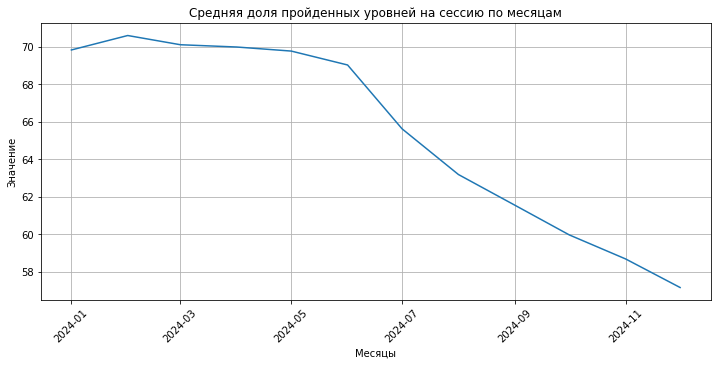

```python
df_sessions['dt'] = pd.to_datetime(df_sessions['time_end']).dt.to_period('M').dt.to_timestamp()
df_grouped = df_sessions.groupby(['dt','device_id','session_id']).agg(success = ('success_fact','sum'),
                                                             total = ('success_fact','count')).reset_index()
df_grouped['success_rate'] = 100*(df_grouped['success']/df_grouped['total'])

df_grouped = df_grouped.groupby('dt')['success_rate'].mean().reset_index()

plt.subplots(figsize=(12,5))
plt.plot(df_grouped['dt'], df_grouped['success_rate'])
plt.title('Cредняя доля пройденных уровней на сессию по месяцам')
plt.xlabel('Месяцы')
plt.ylabel('Значение')
plt.xticks(rotation=45)
plt.grid()
plt.show()
```

**Вывод:** Показатель был практически стабилен до июня месяца, затем резко пошел вниз. Возможно, игра сильно усложнилась или это связано с техническими проблемами, если игра происходит он-лайн.

### ARPAU - средняя выручка (средний доход) на активного пользователя по месяцам

Формула:

ARPAU = Сумма стоимостей успешных покупок пользователей за период / Количество уникальных пользователей за период

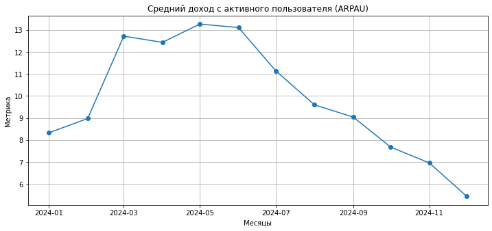

```python
df_transactions['dt'] = pd.to_datetime(df_transactions['time']).dt.to_period('M').dt.to_timestamp()
df_events['dt'] = pd.to_datetime(df_events['time']).dt.to_period('M').dt.to_timestamp()

success_transactions = df_transactions[df_transactions['status'] == 'success']
transactions_sum = success_transactions.groupby('dt')['price'].sum().reset_index()

users_n = df_events.groupby('dt')['device_id'].nunique().reset_index()

merged_df = pd.merge(transactions_sum, users_n, how='inner', on='dt')
merged_df['ARPAU'] = merged_df['price']/merged_df['device_id']

plt.figure(figsize=(12, 5))
plt.plot(merged_df['dt'], merged_df['ARPAU'], marker='o')
plt.title('Средний доход с активного пользователя (ARPAU)')
plt.xlabel('Месяцы')
plt.ylabel('Метрика')
plt.grid()
plt.show()
```

### Продуктовая воронка

Выполним расчёт и визуализацию воронки конверсии в покупку.

События воронки от первого этапа до последнего:

- app_start — запуск приложения (берём за 100% и в визуализацию не включаем);
- store_open — открытие магазина;
- item_add_to_cart — добавление предмета в корзину;
- checkout_load — открытие чекаута;
- order_completed — завершение заказа.

При расчёте используем окно атрибуции, равное 30 дням.

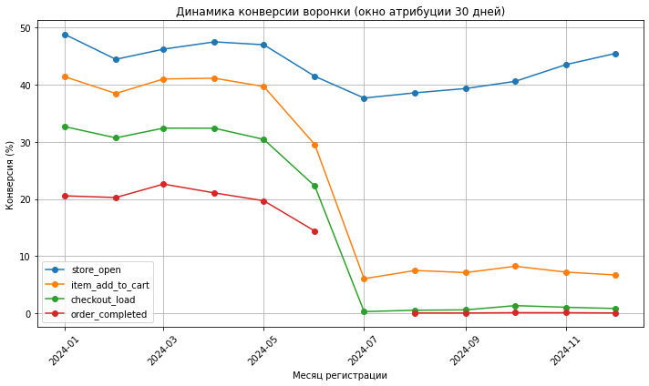

```python
df_events['time'] = pd.to_datetime(df_events['time'])
df_users['install_time'] = pd.to_datetime(df_users['install_time'])

df = pd.merge(df_events, df_users[['device_id','install_time']], on='device_id', how='left')

attribution_window = 30
# Фильтруем события в пределах окна атрибуции

df['diff_days'] = (df['time'] - df['install_time']).dt.days
df['install_month'] = df['install_time'].dt.to_period('M').dt.to_timestamp()
df = df[df['diff_days'].between(0, attribution_window)]

event_list =  ['store_open', 'item_add_to_cart', 'checkout_load','order_completed']
funnel_dynamic = df.groupby('install_month')['device_id'].nunique().reset_index(name='install_devices')

plt.figure(figsize=(10, 6))

for event in event_list:
    df_event = df.loc[df['event_name'] == event].groupby('install_month')['device_id'].nunique().reset_index(name=event)
    funnel_dynamic =  funnel_dynamic.merge(df_event, on='install_month', how='left')
    funnel_dynamic[event] = 100* (funnel_dynamic[event] / funnel_dynamic['install_devices'])
    # Добавляем линию на график
    plt.plot(funnel_dynamic['install_month'], funnel_dynamic[event], marker='o', label=event)

# Оформление графика
plt.title('Динамика конверсии воронки (окно атрибуции 30 дней)')
plt.xlabel('Месяц регистрации')
plt.ylabel('Конверсия (%)')
plt.xticks(rotation=45)
plt.legend()
plt.grid(True)
plt.tight_layout()
plt.show()
```

**Вывод:** Воронка сигнализирует о проблеме уже на верхних этапах, начиная с июня. Если 1 шаг воронки - открытие магазина - конверсия немного падает в июне и июле, но потом стабилизируется и демонстрирует небольшой рост, то 2 шаг воронки - добавление в заказ - начинает падать в июне, сильно падает в июле и далее стабилизируется на низких значениях показателя. Соответственно , так же ведут себя показатели конверсии на следующих шагах воронки.

### Средняя цена предметов в заказе с группировкой по месяцам

Формула:

Средняя цена предметов в заказе за период = Сумма цен всех предметов в заказах за период / Общее количество предметов в заказах за период

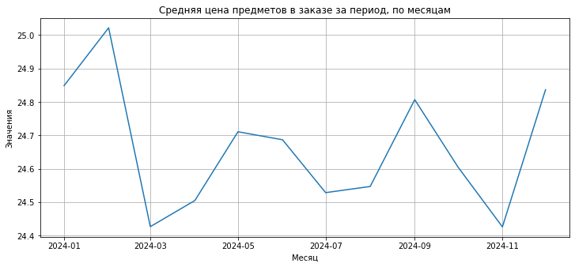

```python
success_transactions = df_transactions.loc[df_transactions['status'] == 'success'].copy()
success_transactions['month'] = pd.to_datetime(success_transactions['time']).dt.to_period('M').dt.to_timestamp()

grouped_transactions = success_transactions.groupby(['month']).agg(
    price_sum=('price', 'sum'),
    item_quantity=('item_name', 'count'))

grouped_transactions = grouped_transactions.groupby('month').agg({'price_sum': 'sum', 'item_quantity': 'sum'}).reset_index()
grouped_transactions['avg_item_price'] = grouped_transactions['price_sum']/grouped_transactions['item_quantity']

plt.subplots(figsize=(12,5))
plt.plot(grouped_transactions['month'], grouped_transactions['avg_item_price'])
plt.title('Средняя цена предметов в заказе за период, по месяцам')
plt.xlabel('Месяц')
plt.ylabel('Значения')
plt.grid()
plt.show()
```

**Вывод:** Показатель демонстрирует равномерные колебания в течение года - от 24,4 до 25. Здесь проблем нет.

### Среднее количество предметов в заказе за период»

Формула:

Среднее количество предметов в заказе за период = Общее количество предметов, которые были в заказах за период / Количество заказов за период

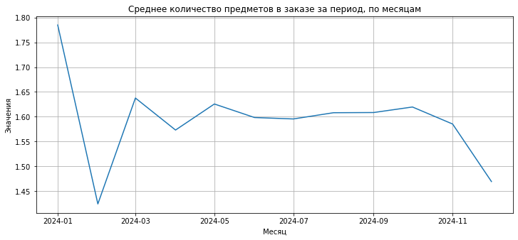

```python
grouped_transactions = success_transactions.groupby(['month']).agg(
   order_quantity=('transaction_id', 'nunique'),
   item_quantity=('item_name', 'count'))

grouped_transactions = grouped_transactions.groupby('month').agg({'order_quantity': 'sum', 'item_quantity': 'sum'}).reset_index()
grouped_transactions['avg_item_count'] = grouped_transactions['item_quantity']/grouped_transactions['order_quantity']

plt.subplots(figsize=(12,5))
plt.plot(grouped_transactions['month'], grouped_transactions['avg_item_count'])
plt.title('Среднее количество предметов в заказе за период, по месяцам')
plt.xlabel('Месяц')
plt.ylabel('Значения')
plt.grid()
plt.show()
```

**Вывод:** Среднее количество предметов в заказе в диапазоне 1,45-1,8. Т.е. обычно рядовой игрок за один раз покупает 1 или 2 предмета. Показатель относительно стабилен.

### Cредний чек с группировкой по месяцам

Формула:

Средний чек = Средняя цена предметов в заказе за период × Среднее количество предметов в заказе за период

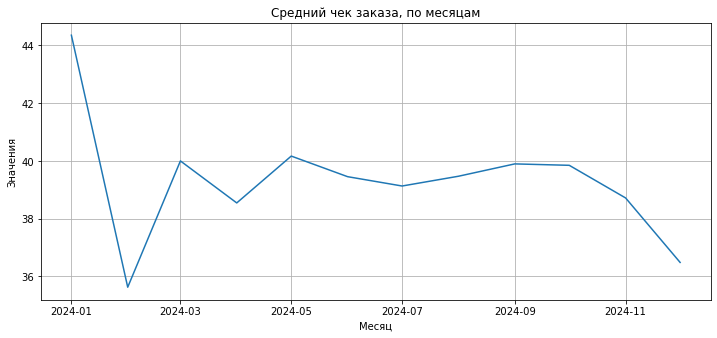

```python
grouped_transactions =success_transactions.groupby(['month']).agg(
   order_quantity=('transaction_id', 'nunique'),
   item_quantity=('item_name', 'count'),
   price_sum=('price', 'sum'))

grouped_transactions=grouped_transactions.groupby('month').agg({
    'order_quantity': 'sum',
    'item_quantity': 'sum',
    'price_sum': 'sum'}).reset_index()

grouped_transactions['avg_item_count'] = grouped_transactions['item_quantity']/grouped_transactions['order_quantity']
grouped_transactions['avg_item_price'] = grouped_transactions['price_sum']/grouped_transactions['item_quantity']
grouped_transactions['AOV'] = grouped_transactions['avg_item_price'] * grouped_transactions['avg_item_count']

plt.subplots(figsize=(12,5))
plt.plot(grouped_transactions['month'], grouped_transactions['AOV'])
plt.title('Средний чек заказа, по месяцам')
plt.xlabel('Месяц')
plt.ylabel('Значения')
plt.grid()
plt.show()
```

**Вывод:** Средний чек относительно стабилен. Он резко упал в феврале (возможно, это сезонность после января), затем стабилизировался, но с снова падает с октября.

### Доля пользователей, у которых пройдено более 10 уровней по месяцам

Формула:

Доля пользователей, у которых пройдено более 10 уровней = Количество пользователей, у которых последний успешно пройденный уровень > 10 по состоянию на период N / Количество пользователей, которые устанавливали приложение по состоянию на период N

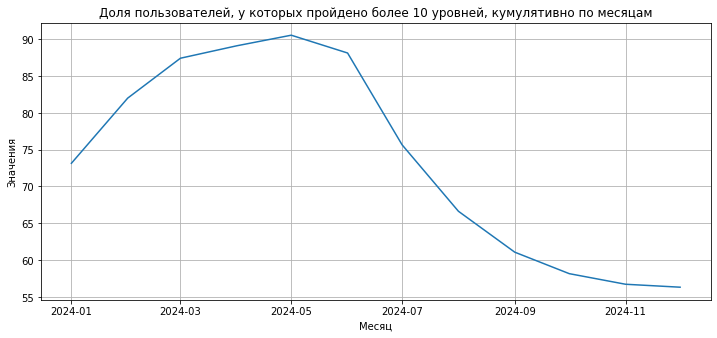

```python
df_sessions['month'] = pd.to_datetime(df_sessions['time_end']).dt.to_period('M').dt.to_timestamp()
df_users['month'] = pd.to_datetime(df_users['install_time']).dt.to_period('M').dt.to_timestamp()

# Выбираем уровень=11 (т.е.человек уже прошел 10 уровней) и пройденные с успехом по пользователю
#df_levels = game_sessions.loc[(game_sessions['level_id'] >= 11) & (game_sessions['success_fact'] == 1)]
df_levels = df_sessions.loc[(df_sessions['level_id'] == 11) & (df_sessions['success_fact'] == 1)]

# Группируем по месяцу
df_levels_grouped = df_levels.groupby('month')['device_id'].nunique().reset_index()

#Считаем кумулятивно количесво пользователей кумулятивно
df_levels_grouped['cumsum_users_level_success'] = df_levels_grouped['device_id'].cumsum()

# Группируем месяц-поличество уникальных пользователей
df_users_grouped = df_users.groupby('month')['device_id'].nunique().reset_index()

# По количеству уникальных пользователей вычисляем кумулятивную сумму пользователей за месяц и предыдущий период
df_users_grouped['cumsum_users_all'] = df_users_grouped['device_id'].cumsum()

table_final = pd.merge(df_levels_grouped, df_users_grouped, on = 'month',how='left')
table_final['levels_finish_rate'] = round(100 * (table_final['cumsum_users_level_success']/
                                                 table_final['cumsum_users_all']), 2)

plt.subplots(figsize=(12,5))
plt.plot(table_final['month'], table_final['levels_finish_rate'])
plt.title('Доля пользователей, у которых пройдено более 10 уровней, кумулятивно по месяцам')
plt.xlabel('Месяц')
plt.ylabel('Значения')
plt.grid()
plt.show()
```

## Выводы по проекту

В проекте проанализированны данные игрового приложения **"Mines & Moles"** на предмет выявления **причин падения ключевой метрики (Revenue).**

Анализ дерева метрик выявил зависимость ключевой метрики от следующих метрик:

- Количество активных пользователей,
- Средняя выручка на активного пользователя.

Т.е. пользователи :

- или технически не могут добавить выбранный товар в заказ
- или не хотят.

**Резюмируем:** Т.к. летом произошли изменения в приложении (редизайн внутриигрового магазина и корректировка алгоритма, который генерирует уровни) можно предположить, что

- уровни игры стали сложнее и проходить их без дополнительно купленной амуниции невозможно;
- добавить «предметы силы» в корзину стало сложнее, возможно, их не видно в игре, или предлагается к покупке не то, что нужно для прохождения уровня или технически невозможно. Это привело к падению количества покупок и, как следствие, к падению выручки.
- Невозможность пройти уровни без дополнительных скиллов или амуниции вызвала падение интереса пользователей к приложению (Retention)

**Рекомендация:** провести опрос пользователей для выявления проблем или в тестовом режиме пройти несколько уровней игры для выявления багов на этапе добавления предметов в заказ во внутриигровом магазине.